# Salad with a Side of Plastic: Comparing Microplastic Pollution in Romaine Lettuce Sold with or without Plastic Packaging

Bailey Lai

2019 May 09

### Abstract

Microplastic contamination, resulting from the breaking down of larger plastic waste, covers vast swathes of the Earth, and its worldwide proliferation has worrying implications for worldwide human health. There is a growing body of research indicating humans are consuming microplastics through a variety of foods, leading to microplastic bioaccumulation that can cause harm to humans. However, most studies have focused on the risk of consuming seafood contaminated with microplastics, especially filtering bivalves. This research aims to investigate microplastic levels in romaine lettuce commercially sold in grocery stores around Claremont, California, investigating whether plastic packaging of pre-washed produce has higher potential for microplastic contamination versus unwashed unpackaged produce. In comparing packaged and unpackaged lettuce, the null hypothesis of “there is no difference in microplastic quantities in romaine lettuce with or without plastic packaging” could not be rejected (parametric test p-value = 0.38; non-parametric test p-value = 0.58). This brings into consideration whether our study can broaden our focus to encapsulate produce exposure to airborne microplastics, the extent of laboratory microplastic contamination and the future of research into the prevalence of microplastics in the larger environment.

### Introduction

Microplastic, generally defined as any small fragments of plastic between 10 micrometers and five millimeters in diameter, presents a major environmental pollution dilemma. The prevalence of plastic in modern society and the inability of most plastic particles, polymers, and fibers to naturally biodegrade mean huge amounts of plastic waste have accumulated across all corners of the globe and through all forms of human products (GESAMP 2016; Andrady 2017). Wherever microplastics end up, they accumulate in biota, some of which ends up consumed by humans. The long-term effects of microplastics in humans are not fully understood, but plastic additives and its bonds with toxic materials can potentially cause adverse health effects for humans. Despite this, there is still much research to be done on microplastics found in consumed foods aside from seafood, such as in produce. This study aims to determine whether commercially-sold produce wrapped in plastic packaging, such as pre-washed romaine lettuce, changes the amount of microplastic deposited on its surface (and therefore consumed) as opposed to produce sold without packaging.

Most existing microplastic research focuses on microplastic accumulated in marine life and commercially-sold seafood like bivalves (Cauwenberghe and Jannsen 2014). This means there has been a surprising lack of research on terrestrial microplastic bioaccumulation in the past (Rillig 2012). Though plastics can break down into smaller sizes, plastic polymers do not easily break down at the microscopic and molecular level (Liboiron 2015). The toxic materials that bond with plastics at the microscopic level ultimately make microplastics such a pressing health issue for plants, animals, humans, and other living organisms (Liboiron 2015). des Rieux et al. (2005) found that ingested nanoparticles can affect transcellular transport using in vitro models of follicle associated epthelium (FAE) in the human intestine, with amine nanoparticles (consisting of a nitrogen atom and lone pair) transported more easily than carboxyl nanoparticles (containing the atoms COOH), suggesting functional groups of plastic nanoparticle compounds play a role in absorption through the intestines. In addition, other studies have shown common plastic additives like phthalates and Bisphenol A (BPA) can affect the hormone systems of different organisms (Machado et al. 2017). Because most microplastics research is in the past decade, there is no scientific consensus on how significant long-term and continuous ingestion of microplastics in food is when compared to overall microplastic exposure. By investigating produce at the stage of production nearest to consumption (in the grocery store), this research aims to begin to create a more robust understanding of how all foodways impact human microplastic exposure, and how processing tactics, such as packaging, play a role in exposure.

Multiple overarching questions are therefore developed to conduct this research. Are microplastics found in romaine lettuce intended for human consumption? If yes, do microplastic concentrations vary depending on whether or not they were sold in plastic packaging at the point of purchase? Because of romaine lettuce’s availability both in unpackaged heads and prepared plastic bags, it serves as the ideal produce through which to investigate how the phenomenon of how packaging impacts microplastic exposure and subsequent leaching. Furthermore, this research will be conducted using a hypothesis test, where a null hypothesis will be rejected or not rejected based on whether a p-value of < 0.05 is obtained. For the purpose of this research, the null hypothesis is “there is no difference in microplastic quantities in romaine lettuce sold with or without plastic packaging.” Our alternative hypothesis is that there is a statistically significant difference in microplastic counts from romaine lettuce sold with plastic packaging versus romaine lettuce sold without. This metric will be used to assess the impact of plastic packaging on microplastic in commercially-sold produce.

By conducting this study, we hope to better understand the exposure to microplastics in situations aside from eating seafood and marine life. The prevalence of plastics in today’s world means microplastics are found and inevitably ingested by humans on a daily basis. What microplastic ingestion means for the long-term health effects on humans is not yet fully understood, but we do know that plastics in general can leach harmful chemicals and also can attract toxic chemicals onto its surface. Studying the presence of microplastics in a commonly packaged grocery item like romaine lettuce can give us more insight to how plastics get into our digestive systems and perhaps lead us to solutions for reducing plastic contamination in our everyday lives.

### Methods

The following methods are based off of prior established methods for obtaining microplastic counts from food products (Löder et al. 2017, Maes et al. 2017, Karlsson et al. 2017, and Quinn et al. 2018).

We purchased two unpackaged heads of romaine lettuce and two bags of romaine lettuce in plastic packaging from each of the chosen five stores in the cities of Claremont and Pomona. We chose only stores that sell both unpackaged heads AND packaged lettuce (lettuce packaged as chopped salad is acceptable). This led us to select the following supermarkets: Sprouts on Foothill Blvd, Stater Bros. on N Garey Ave, Cardenas on E Holt Ave, El Super on E Holt Ave, and Super King on Auto Center Dr. We put the unpackaged romaine lettuce into paper bags to minimize contamination during transit.

In the lab, we used a glass blender to homogenize the lettuce with water. All equipment in contact with lettuce were first thoroughly washed with Milli-Q deionized water for each successive sample. For each sample of unbagged lettuce, we washed the head in Milli-Q deionized water, then tore out leaves and inserted them into the blender until it reached the top. Bagged lettuce was not washed, since they are labeled “pre-washed” and we wanted to test the difference. Bagged lettuce was poured straight from the bag into the blender until it reached the top. Afterwards, we poured in 200 mL of Milli-Q deionized water into the blender. We blended the mix of lettuce and water for 30 seconds under the slower “stir/grind” setting, then 60 seconds under the faster “cream/fruit smoothie” setting. We strained the homogenized lettuce and water through a 5 mm stainless steel sieve into a glass beaker to obtain 100 mL of solution. This process was repeated for each sample, for a total of 20 experimental samples (two unbagged, two bagged from each of the five stores).

To break down the cellulose in the lettuce solution, we added 5 mL cellulase from *Aspergillus niger* to separate particles in the solution by density, and then we added 10 mL phosphate-buffered saline (PBS) to each beaker. 1 L of phosphate-buffered saline solution was prepared using 8 g sodium chloride (NaCl), 200 mg potassium chloride (KCl), 1.44 g disodium phosphate (Na<sub>2</sub>HPO<sub>4</sub>), and 240 mg monopotassium phosphate (KH<sub>2</sub>PO<sub>4</sub>) prepared in deionized water, then set to pH 5 using hydrochloric acid (HCl). Three blank control samples were prepared using 100 mL Milli-Q deionized water in a glass beaker. The beakers were then covered with aluminium foil wrap and incubated at 50°C for four days.

After incubation, we added 50 mL NaCl solution to each beaker (density = 1.2 g NaCl / 1 mL water, 1440 mL solution stirred in 2 L volumetric flask for 10 minutes). For each beaker, 5 mL of 0.08 g/mL Red Nile dye solution was added and allowed to stain the sample solution for 30 minutes. For each of the 23 total samples, 40 mL of solution was extracted from the top of the beaker using a glass vacuum and glass pipette through a sheet of filter paper. The filter paper was placed in glass containers and covered with aluminium foil to let dry overnight. We then used a digital microscope with fluorescent light (red fluorescent 100% brightness, 110 ms capture) to count stained microplastic particles next to four randomly generated points at 4X zoom for each sample of filter paper (Figure 1). Four microplastic counts were obtained for each of the 20 experimental samples and 3 blank samples.

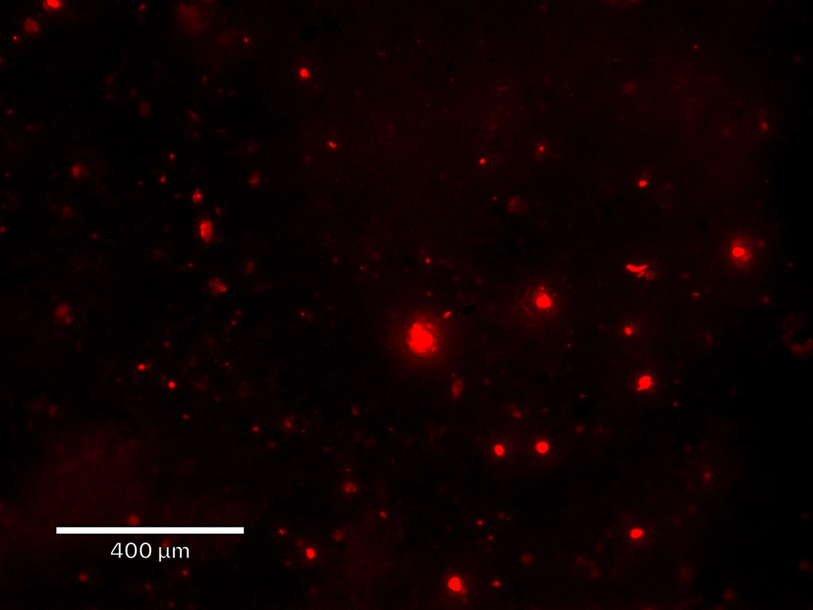

**Figure 1.** The image captured by the Revolve digital microscope for Sprouts Unbagged Sample #2, point 1.

Statistical analysis was conducted using the program R (R Core Team 2019). In the analysis, we calculated the average of the eight unbagged counts and the average of the eight bagged counts for each of the five stores, giving us five bagged averages and five unbagged averages. We compared each store’s bagged versus unbagged average with the parametric paired t-test (for normal distribution) and nonparametric paired Wilcoxon signed-rank test (for non-normal distribution), obtaining one p-value for each of the two tests.

### Results

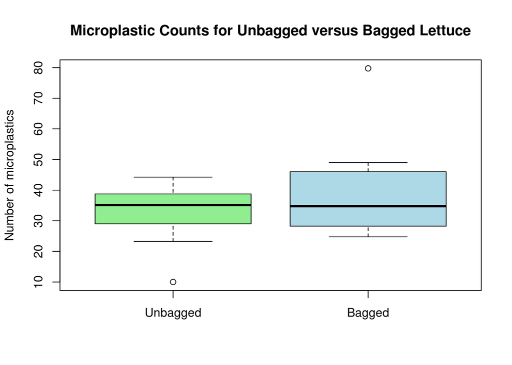

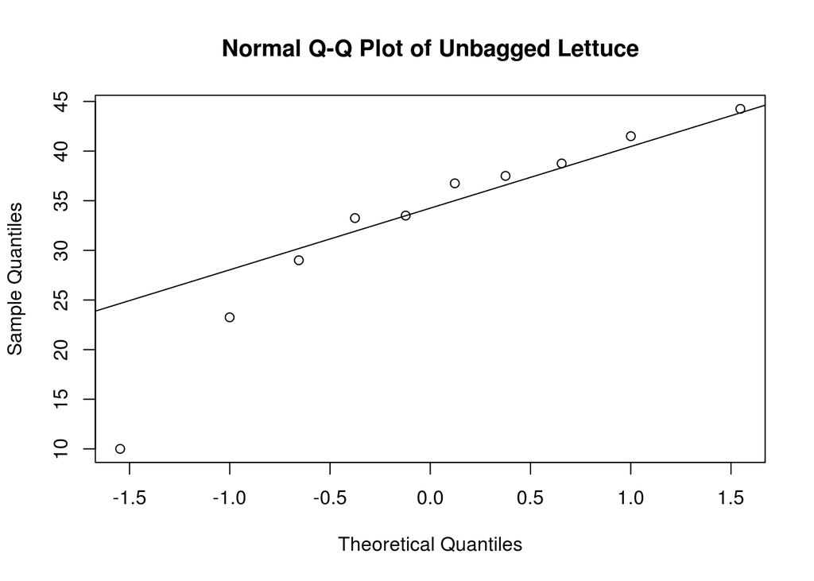

**Figure 2.** Normal Q-Q Plot of Unbagged Lettuce

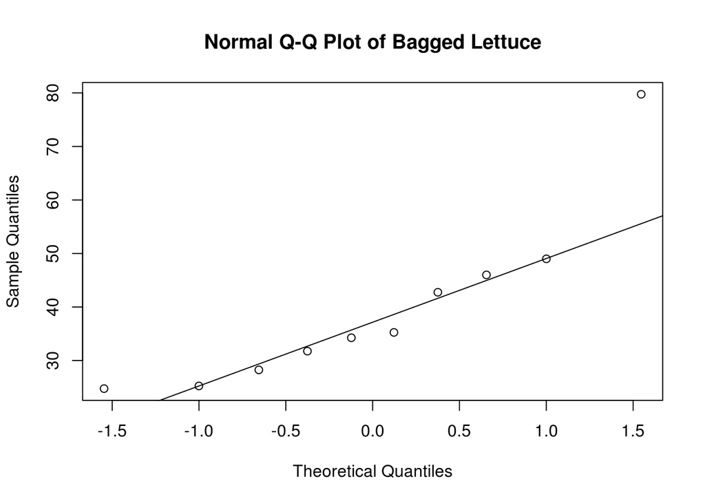

**Figure 3.** Normal Q-Q Plot of Bagged Lettuce

| Type | Average Count | Net Experimental Count |
| --- | --- | --- |
| Unbagged | 32.775 | 8.025 |
| Bagged | 39.700 | 14.950 |
| Blank | 24.750 | - |

**Table 1.** Average Microplastic Count in Grocery-Bought Romaine Lettuce

| Test | p-value | Statistical significance? |
| --- | --- | --- |
| 1. paired t-test | 0.38 | no |
| 2. Wilcoxon signed-rank test | 0.58 | no |

**Table 2.** Test of differences between bagged and unbagged microplastic counts paired with each store

### Discussion

The high p-value in both the non-parametric test and parametric test indicates the difference between the bagged and unbagged microplastic counts are not statistically significant. One possible reason is the amount of microplastics deposited in produce wrapped in plastic packaging may be comparable to the amount deposited on unbagged produce in transit and processing as airborne plastic dust. Bagged lettuce may be exposed to high amounts of microplastic in the processing plant, but is washed prior to being air-sealed until consumption. Unbagged lettuce, on the other hand, is exposed to any outside dust pollution that settles on its surface from the processing facility to the grocery aisle and the trip from the supermarket to the consumer’s kitchen. Microplastics can be introduced to any time in the production and transportation of produce, all the way up to consumption.

Most food bought in groceries and stores today go through many manufacturing processes and machinery, putting products into contact with plastic residue and potential contaminants.Considering the probability of airborne microplastics cross-contaminating controlled indoor lab experiments, commercially-available produce harvested & processed by plastic machinery and/or sold in wrapped plastics will likely contain microplastic as well (Machado et al. 2017). Multiple studies have shown commercial food products like honey, table salt, beer contain trace amounts of microplastic fibers (Karami et al. 2017, Iñiguez et al. 2017, Liebezeit and Liebezeit 2013, 2014). One study has shown that microplastics can be found in agricultural fields that use fertilizer from human wastewater systems (Machado et al 2017). This raises the question of whether comparing bagged and unbagged produce is appropriate, or if future research should explore microplastic consumption in a larger context of surrounding microplastic in existing agricultural practices and built environments.

No investigation into microplastics in produce has been conducted before, making the process of creating procedures difficult. However, in the non-seafood studies evaluated, microplastic quantities were between 1-660 microplastics per kilogram of substance. As with all investigations into microplastics in foods, there is significant risk of sample contamination, which may explain the extreme variation in numbers. Additionally, three of the four studies found minimus of 16-50 microplastics per kilogram, and maximums of 254-660 microplastics per kilogram, fairly comparable numbers when contamination and random variation is considered. The microplastics found in romaine lettuce heads may fall within these boundaries (Karami et al. 2017, Iñiguez et al. 2017 Liebezeit and Liebezeit 2013, 2014). However, as with most microplastic studies, some potential confounding factors do exist.

Our methodology may also impacted the final counts. One issue arose with the way in which we obtained the sample solution. When we used a sieve to filter the blended lettuce water, most of the visible fibre solids congealed atop the sieve, potentially filtering out microplastics among the lettuce from the resulting solution we tested. Contamination of samples is a major concern, via airborne particulates, plastics which may remain in deionized water, and the presence of plastics (clothing, equipment, etc) in the lab. Another issue we ran into was how to quantify dyed particles. Though most particles appeared circular and artificial and most likely microplastic, it was hard to assess whether some dyed material were plastic or lettuce fibres and strands. If time permits, future studies can look into digesting more of the lettuce fibres with the multi-week enzymatic digestions described in Löder et al. (2017), rather than separating most of the solids with a sieve and using one enzymatic digestion. This may provide a more encompassing and accurate microplastic count.

### Conclusion

Our study did not find a statistically significant difference in microplastic counts between romaine lettuce sold pre-washed in plastic packaging versus romaine lettuce sold unpackaged. Though our study did not have conclusive findings, future microplastics research is highly needed based on the little literature we found on microplastics in produce and in terrestrial environments. The fact that we counted microplastics in all our samples, even in the blanks, suggests microplastics are omnipresent in our lives. This reality underscores the necessity, discussed by Rist et al. (2018), of expanding and contextualizing the debate around microplastics. After all, food consumption is still just one of many possible ways in which we can get exposed to microplastic pollution every day. The larger implications of airborne microplastics within produce facilities or carried around the atmosphere by wind, as well as the processes of microplastic accumulation in agricultural fields and other land-based ecosystems should be better understood to best grapple with increasing plastics in our world.

### Works Cited

Andrady, AL. 2017. The plastic in microplastics: a review. Mar Pollut Bull [Internet]. [published 2017 Jan 30; cited 2019 Mar 30]; 119: 12-22.

Claessens M, Van Cauwenberghe L, Vandegehuchte MB, Janssen CR. 2013. New techniques for the detection of microplastics in sediments and field collected organisms. Mar Pollut Bul [Internet]. [published 2013 May 15; cited 2019 Mar 31]; 70(1-2): 227-233.

des Rieux A, Ragnarsson EG, Gullberg E, Préat V, Schneider YJ, Artursson P. 2005. Transport of nanoparticles across an in vitro model of the human intestinal follicle associated epithelium. Eur J Pharm Sci [Internet]. [cited 2019 Apr 08]; 25(4-5): 455-465.

[GESAMP] Joint Group of Experts on the Scientific Aspects of Marine Environmental Protection. 2016. Sources, Fate And Effects Of Microplastics In The Marine Environment: Part Two Of A Global Assessment. GESAMP [Internet]. [cited 2019 Apr 08]; 93:1-220.

Iñiguez M, Conesa J, Fullana A. 2017. Microplastics in Spanish Table Salt. Scientific Reports [Internet]. [cited 2019 Apr 08]; 7:8620.

Karami A, Golieskardi A, Choo C, Larat V, Galloway T, Salamatinia B. 2017. The presence of microplastics in commercial salts from different countries. Nature Scientific Articles [Internet]. [cited 2019 Apr 08]; 7: 46173.

Karlsson T, Vethaak A, Almrothd B, Ariese F, van Velzen M, Hassellöv M, Leslie H. 2017. Screening for microplastics in sediment, water, marine invertebrates and fish: Method development and microplastic accumulation. Mar Pollut Bul [Internet]. [cited 2019 Apr 08]; 122:403-408.

Kühn S, Rebolledo ELB, Van Franeker JA. 2015. Deleterious effects of litter on marine life. Mar Anthro Litter [Internet]. [cited 2019 Apr 08]; 75–116.

Liboiron M. 2016. Redefining pollution and action: the matter of plastics. J Material Cult [Internet]. [cited 2019 Mar 30]; 21(1): 87-110.

Liebezeit G, Liebezeit E. 2013. Non-pollen particulates in honey and sugar. Food Additives & Contaminants: Part A [Internet]. [cited 2019 Mar 30]; 30(12):2136-2140.

Liebezeit G, Liebezeit E. 2014. Synthetic particles as contaminants in German beer. Food Additives & Contaminants: Part A [Internet]. [cited 2019 Mar 30]; 31(9):1574-1578.

Löder M, Imhof H, Ladehoff M, Löschel L, Lorenz C, Mintenig S, Piehl S, Primpke S, Schrank I, Laforsch C, Gerdts G. 2017. Enzymatic Purification of Microplastics in Environmental Samples. Enviro Sci Technol [Internet]. [cited 2019 Mar 30]; 51:14283-14292.

Maes T, Jessop R, Wellner N, Haupt K, Mayes A. 2017. A rapid-screening approach to detect and quantify microplastics based on fluorescent tagging with Nile Red. Sci Reports [Internet]. [cited 2019 Apr 08]; 7:44501.

Machado AAS, Kloas W, Zarfl C, Hempel S, Rillig MC. 2017. Microplastics as an emerging threat to terrestrial ecosystems. Glob Change Biol [Internet]. [published 2017 December 15; cited 2019 March 31]; 24(4): 1405-1416.

R Core Team. 2019. R: A language and environment for statistical computing. R Foundation for Statistical Computing [Internet]. http://www.R-project.org/.

Rillig MC. 2012. Microplastic in terrestrial ecosystems and the soil? Environ Sci Technol [Internet]. [published 2012 May 31; cited 2019 April 01] 46: 6453-6454.

Quinn B, Murphy F, Ewins. 2017. Validation of density separation for the rapid recovery of microplastics from sediment. Anal Methods [Internet]. [cited 2019 Apr 01]; 9(9):1491-1498.